# Working_Document

Harold Trammel

October 10, 2015

## Question

### Weight Lifting Exercises Dataset

In this work (see the paper) we first define quality of execution and investigate three aspects that pertain to qualitative activity recognition: the problem of specifying correct execution, the automatic and robust detection of execution mistakes, and how to provide feedback on the quality of execution to the user. We tried out an on-body sensing approach (dataset here), but also an “ambient sensing approach” (by using Microsoft Kinect - dataset still unavailable)

Six young health participants were asked to perform one set of 10 repetitions of the Unilateral Dumbbell Biceps Curl in five different fashions: exactly according to the specification (Class A), throwing the elbows to the front (Class B), lifting the dumbbell only halfway (Class C), lowering the dumbbell only halfway (Class D) and throwing the hips to the front (Class E).

Class A corresponds to the specified execution of the exercise, while the other 4 classes correspond to common mistakes. Participants were supervised by an experienced weight lifter to make sure the execution complied to the manner they were supposed to simulate. The exercises were performed by six male participants aged between 20-28 years, with little weight lifting experience. We made sure that all participants could easily simulate the mistakes in a safe and controlled manner by using a relatively light dumbbell (1.25kg).

Please, cite this paper to refer the WLE dataset

Velloso, E.; Bulling, A.; Gellersen, H.; Ugulino, W.; Fuks, H. Qualitative Activity Recognition of Weight Lifting Exercises. Proceedings of 4th International Conference in Cooperation with SIGCHI (Augmented Human ’13) . Stuttgart, Germany: ACM SIGCHI, 2013.

Read more: http://groupware.les.inf.puc-rio.br/har#ixzz3oBl7KBCe

### Data Exploration

```r
require(dplyr)
```

```r
require(ggplot2)
require(tidyr)
require(reshape2)
train1_df <- read.csv("./Data/pml-training.csv")

base_df <- select(train1_df, one_of("X","user_name","classe"))
# keep only the index id, user_name, class, and accelarometer data
accel_df <-  cbind(base_df, select(train1_df, contains("accel")))

summary(accel_df)
```

```
##        X            user_name    classe   total_accel_belt
##  Min.   :    1   adelmo  :3892   A:5580   Min.   : 0.00
##  1st Qu.: 4906   carlitos:3112   B:3797   1st Qu.: 3.00
##  Median : 9812   charles :3536   C:3422   Median :17.00
##  Mean   : 9812   eurico  :3070   D:3216   Mean   :11.31
##  3rd Qu.:14717   jeremy  :3402   E:3607   3rd Qu.:18.00
##  Max.   :19622   pedro   :2610            Max.   :29.00
##
##  var_total_accel_belt  accel_belt_x       accel_belt_y
##  Min.   : 0.000       Min.   :-120.000   Min.   :-69.00
##  1st Qu.: 0.100       1st Qu.: -21.000   1st Qu.:  3.00
##  Median : 0.200       Median : -15.000   Median : 35.00
##  Mean   : 0.926       Mean   :  -5.595   Mean   : 30.15
##  3rd Qu.: 0.300       3rd Qu.:  -5.000   3rd Qu.: 61.00
##  Max.   :16.500       Max.   :  85.000   Max.   :164.00
##  NA's   :19216
##   accel_belt_z     total_accel_arm var_accel_arm     accel_arm_x
##  Min.   :-275.00   Min.   : 1.00   Min.   :  0.00   Min.   :-404.00
##  1st Qu.:-162.00   1st Qu.:17.00   1st Qu.:  9.03   1st Qu.:-242.00
##  Median :-152.00   Median :27.00   Median : 40.61   Median : -44.00
##  Mean   : -72.59   Mean   :25.51   Mean   : 53.23   Mean   : -60.24
##  3rd Qu.:  27.00   3rd Qu.:33.00   3rd Qu.: 75.62   3rd Qu.:  84.00
##  Max.   : 105.00   Max.   :66.00   Max.   :331.70   Max.   : 437.00
##                                    NA's   :19216
##   accel_arm_y      accel_arm_z      total_accel_dumbbell
##  Min.   :-318.0   Min.   :-636.00   Min.   : 0.00
##  1st Qu.: -54.0   1st Qu.:-143.00   1st Qu.: 4.00
##  Median :  14.0   Median : -47.00   Median :10.00
##  Mean   :  32.6   Mean   : -71.25   Mean   :13.72
##  3rd Qu.: 139.0   3rd Qu.:  23.00   3rd Qu.:19.00
##  Max.   : 308.0   Max.   : 292.00   Max.   :58.00
##
##  var_accel_dumbbell accel_dumbbell_x  accel_dumbbell_y  accel_dumbbell_z
##  Min.   :  0.000    Min.   :-419.00   Min.   :-189.00   Min.   :-334.00
##  1st Qu.:  0.378    1st Qu.: -50.00   1st Qu.:  -8.00   1st Qu.:-142.00
##  Median :  1.000    Median :  -8.00   Median :  41.50   Median :  -1.00
##  Mean   :  4.388    Mean   : -28.62   Mean   :  52.63   Mean   : -38.32
##  3rd Qu.:  3.434    3rd Qu.:  11.00   3rd Qu.: 111.00   3rd Qu.:  38.00
##  Max.   :230.428    Max.   : 235.00   Max.   : 315.00   Max.   : 318.00
##  NA's   :19216
##  total_accel_forearm var_accel_forearm accel_forearm_x   accel_forearm_y
##  Min.   :  0.00      Min.   :  0.000   Min.   :-498.00   Min.   :-632.0
##  1st Qu.: 29.00      1st Qu.:  6.759   1st Qu.:-178.00   1st Qu.:  57.0
##  Median : 36.00      Median : 21.165   Median : -57.00   Median : 201.0
##  Mean   : 34.72      Mean   : 33.502   Mean   : -61.65   Mean   : 163.7
##  3rd Qu.: 41.00      3rd Qu.: 51.240   3rd Qu.:  76.00   3rd Qu.: 312.0
##  Max.   :108.00      Max.   :172.606   Max.   : 477.00   Max.   : 923.0
##                      NA's   :19216
##  accel_forearm_z
##  Min.   :-446.00
##  1st Qu.:-182.00
##  Median : -39.00
##  Mean   : -55.29
##  3rd Qu.:  26.00
##  Max.   : 291.00
##
```

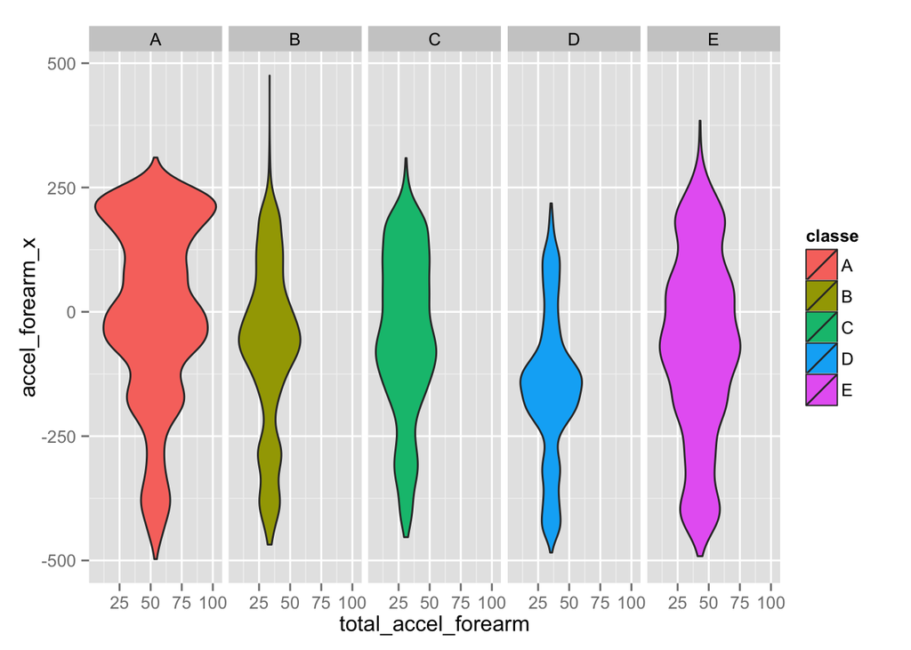

```r
# drop the var_ variables as they are mostly NA
accel_df <- select(accel_df, -starts_with("var_"))

#forearm
fore_df <-  cbind(base_df, select(accel_df, contains("fore")))
fore_pl <- ggplot(fore_df, aes(x=total_accel_forearm, fill=classe)) +
    geom_violin(aes(y=accel_forearm_x)) +
    facet_grid(.~classe)
print(fore_pl)
```

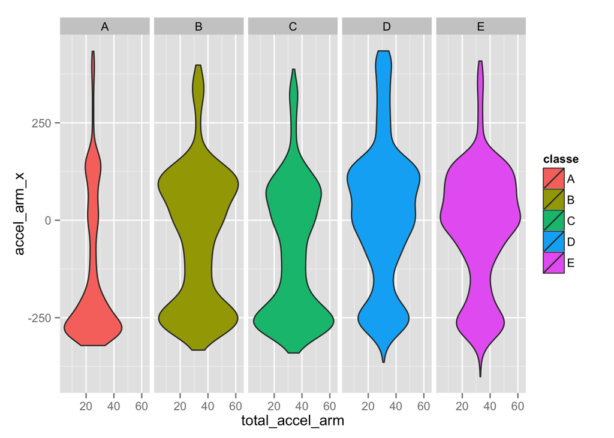

```r
#arm
arm_df <-  cbind(base_df, select(accel_df, contains("_arm")))
arm_pl <- ggplot(arm_df, aes(x=total_accel_arm, fill=classe)) +
    geom_violin(aes(y=accel_arm_x)) +
    facet_grid(.~classe)
print(arm_pl)
```

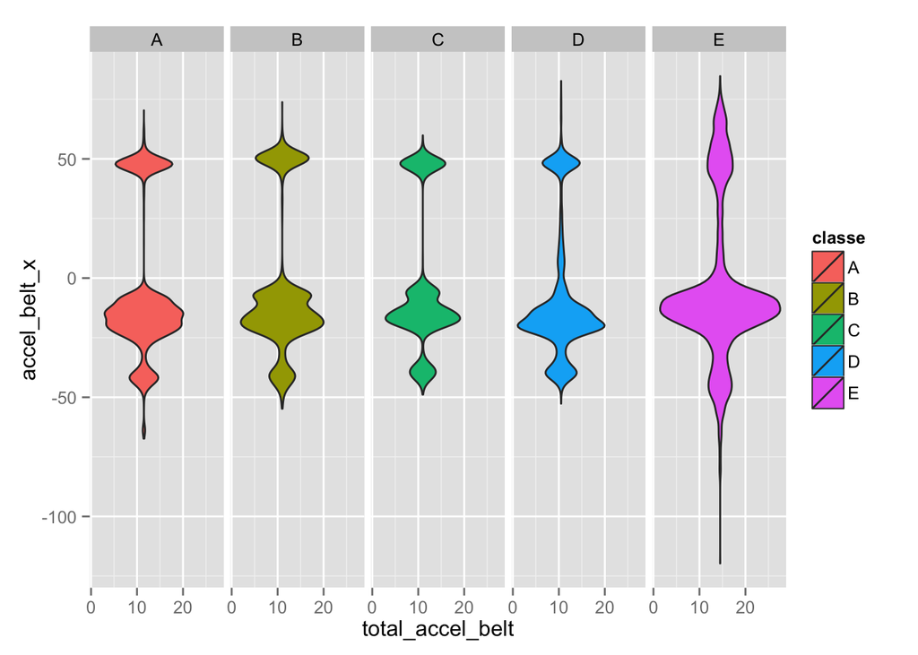

```r
#belt
belt_df <-  cbind(base_df, select(accel_df, contains("belt")))
belt_pl <- ggplot(belt_df, aes(x=total_accel_belt, fill=classe)) +
    geom_violin(aes(y=accel_belt_x)) +
    facet_grid(.~classe)
print(belt_pl)
```

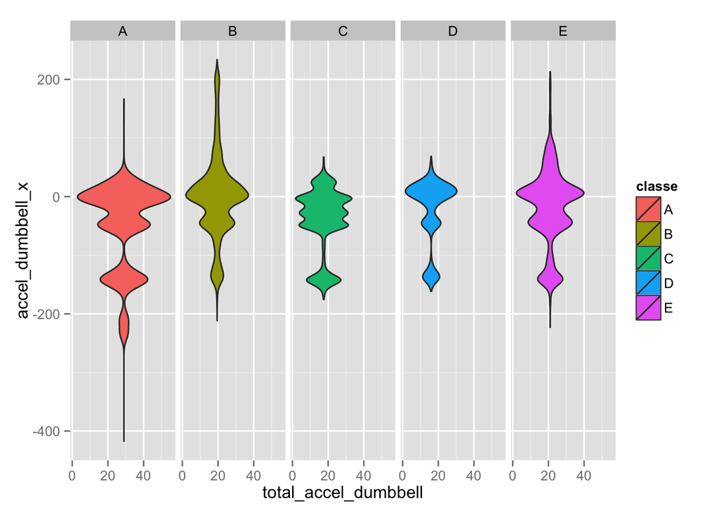

```r
#dumbbell
dumb_df <-  cbind(base_df, select(accel_df, contains("dumbbell")))
dumb_pl <- ggplot(dumb_df, aes(x=total_accel_dumbbell, fill=classe)) +
    geom_violin(aes(y=accel_dumbbell_x)) +
    facet_grid(.~classe)
print(dumb_pl)
```